# Balance Assessment and Survival Analysis | Tamsulosin vs 5ARI

Jacob Simmering, PhD https://jacobsimmering.com (University of Iowa)https://uiowa.edu  
2022-05-09

```r
library("Rcpp", lib.loc = "~/R/x86_64-pc-linux-gnu-library/4.0/")
library(tidyverse)
library(gtsummary)
library(survival)
library(effectsize)
library(patchwork)
```

This file was compiled on 2022-05-09 14:51:26 by `jsimmeri` on argon-lc-f14-25.hpc.

The script `analysis_functions.R` provides:

1. some functions for summarizing the cohort and building tables that are shared across scripts
2. code to load the entire collection out outcomes data (which it returns as `model_data` to the workspace)
3. sets `root_dir` according to the location where the script is being run to handle different syntax for referring to network drives in MacOS and CentOS

```r
source("~/projects/pd-preprint/analysis/analysis_functions.R")
```

## Data Load

### Unadjusted Data

The tibble `model_data` is loaded by `analysis_functions` from /Shared/lss_jsimmeri_backup/data/tz-5ari-final. `model_data` contains data on all users of the three drugs. We want to reduce that here to just tamsulosin and 5ARI.

```r
model_data <- model_data %>%
  filter(drug %in% c("5ari", "tamsulosin")) %>%
  mutate(treatment = drug == "tamsulosin")
```

### Matches

We also want to load our matching results:

```r
matches <- read_rds(glue::glue("{root_dir}/matches/tam_5ari.rds"))
```

And using the matches, build matched versions of the tamsulosin versus 5ARI model data:

```r
matched_model_data <- model_data %>%
  select(-treatment) %>%
  inner_join(matches,
    by = "enrolid")
```

## Balance and Cohort Description

### Before Matching

```r
describe_cohort(model_data)
```

[output not shown]

1Cohen's D  
2CI = Confidence Interval

### After Matching

```r
describe_cohort(matched_model_data)
```

| Group | Characteristic | 5ari, N = 78,747 | tamsulosin, N = 78,747 | Difference1 | 95% CI12 |
| --- | --- | --- | --- | --- | --- |
| Age and Medication Start Time | Age at Index Date | 62 (54, 70) | 62 (54, 71) | -0.002 | -0.011, 0.008 |
|  | Medication Index Date | 2,010.0 (2,008.0, 2,013.0) | 2,010.0 (2,008.0, 2,013.0) | -0.010 | -0.020, 0.000 |
| Duration of Enrollment Time | Lookback Time (Years) | 3.15 (1.84, 5.57) | 3.31 (1.92, 5.78) | -0.059 | -0.069, -0.050 |
|  | Follow Up Time (Years) | 2.22 (0.98, 4.41) | 2.23 (0.98, 4.41) | 0.000 | -0.009, 0.010 |
| Rates of Inpatient and Outpatient Encounters | Inpatient Events Per Year | 0.00 (0.00, 0.00) | 0.00 (0.00, 0.00) | -0.016 | -0.026, -0.006 |
|  | Outpatient Events Per Year | 9 (5, 16) | 9 (5, 16) | -0.012 | -0.022, -0.002 |
|  | Mean Number of DX Codes Per Outpatient Event | 1.41 (1.20, 1.87) | 1.41 (1.20, 1.88) | -0.006 | -0.015, 0.004 |
|  | Outpatient DX Code Incidence Per Year | 0.04 (0.02, 0.07) | 0.04 (0.02, 0.07) | -0.015 | -0.025, -0.005 |
|  | mean_ndx_out_rate | 13 (7, 24) | 13 (7, 24) | -0.015 | -0.025, -0.005 |
| Elixhauser/AHRQ Comorbidity Flags | Alcohol Abuse | 1,135 (1.4%) | 1,197 (1.5%) | -0.007 | -0.016, 0.003 |
|  | Anemia | 9,030 (11.5%) | 9,143 (11.6%) | -0.004 | -0.014, 0.005 |
|  | Blood Loss | 886 (1.1%) | 888 (1.1%) | 0.000 | -0.010, 0.010 |
|  | Heart Failure | 5,180 (6.6%) | 5,327 (6.8%) | -0.007 | -0.017, 0.002 |
|  | Coagulopathy | 2,296 (2.9%) | 2,388 (3.0%) | -0.007 | -0.017, 0.003 |
|  | Depression | 5,370 (6.8%) | 5,417 (6.9%) | -0.002 | -0.012, 0.008 |
|  | Diabetes Without Complications | 15,690 (19.9%) | 16,026 (20.4%) | -0.011 | -0.021, -0.001 |
|  | Diabetes With Complications | 5,004 (6.4%) | 5,302 (6.7%) | -0.015 | -0.025, -0.005 |
|  | Drug Abuse | 567 (0.7%) | 669 (0.8%) | -0.015 | -0.025, -0.005 |
|  | Fluid or Electrolyte Disorders | 5,808 (7.4%) | 6,022 (7.6%) | -0.010 | -0.020, 0.000 |
|  | HIV | 520 (0.7%) | 522 (0.7%) | 0.000 | -0.010, 0.010 |
|  | HTN Without Complications | 41,657 (52.9%) | 41,763 (53.0%) | -0.003 | -0.013, 0.007 |
|  | HTN With Complications | 7,807 (9.9%) | 8,004 (10.2%) | -0.008 | -0.018, 0.002 |
|  | Hypothyroidism | 6,900 (8.8%) | 7,077 (9.0%) | -0.008 | -0.018, 0.002 |
|  | Liver Disease | 2,452 (3.1%) | 2,567 (3.3%) | -0.008 | -0.018, 0.002 |
|  | Lymphoma | 825 (1.0%) | 874 (1.1%) | -0.006 | -0.016, 0.004 |
|  | Metastatic Cancer | 1,087 (1.4%) | 1,165 (1.5%) | -0.008 | -0.018, 0.002 |
|  | Other Neurologic Disorders | 4,415 (5.6%) | 4,593 (5.8%) | -0.010 | -0.020, 0.000 |
|  | Obesity | 4,461 (5.7%) | 4,701 (6.0%) | -0.013 | -0.023, -0.003 |
|  | Paralysis | 959 (1.2%) | 1,005 (1.3%) | -0.005 | -0.015, 0.005 |
|  | Pulmonary Hypertension | 1,520 (1.9%) | 1,658 (2.1%) | -0.012 | -0.022, -0.003 |
|  | Psychoses | 4,086 (5.2%) | 4,166 (5.3%) | -0.005 | -0.014, 0.005 |
|  | Peptic Ulcer Disease | 183 (0.2%) | 210 (0.3%) | -0.007 | -0.017, 0.003 |
|  | COPD | 13,956 (17.7%) | 14,204 (18.0%) | -0.008 | -0.018, 0.002 |
|  | Peripheral Vascular Disease | 8,241 (10.5%) | 8,520 (10.8%) | -0.011 | -0.021, -0.002 |
|  | Renal Failure | 3,429 (4.4%) | 3,546 (4.5%) | -0.007 | -0.017, 0.003 |
|  | Rheumatoid Arthritis | 2,783 (3.5%) | 2,887 (3.7%) | -0.007 | -0.017, 0.003 |
|  | Solid Tumor | 10,368 (13.2%) | 11,007 (14.0%) | -0.024 | -0.034, -0.014 |
|  | Valvular Disease | 9,068 (11.5%) | 9,265 (11.8%) | -0.008 | -0.018, 0.002 |
|  | Weight Loss | 2,212 (2.8%) | 2,292 (2.9%) | -0.006 | -0.016, 0.004 |
| Hypotension | Orthostatic Hypotension | 745 (0.9%) | 766 (1.0%) | -0.003 | -0.013, 0.007 |
|  | Other Hypotension | 1,450 (1.8%) | 1,460 (1.9%) | -0.001 | -0.011, 0.009 |
| Prostate Specific Antigen | PSA Measurement Taken | 47,756 (60.6%) | 47,798 (60.7%) | -0.001 | -0.011, 0.009 |
|  | Diagnosis of Abnormal PSA | 23,236 (29.5%) | 23,361 (29.7%) | -0.003 | -0.013, 0.006 |
| Bladder Function and Urinary Flow | Slow Urinary Stream Diagnosis | 1,934 (2.5%) | 1,944 (2.5%) | -0.001 | -0.011, 0.009 |
|  | Uroflow Study Performed | 5,524 (7.0%) | 5,752 (7.3%) | -0.011 | -0.021, -0.001 |
|  | Cystometrogram Performed | 524 (0.7%) | 572 (0.7%) | -0.007 | -0.017, 0.003 |
|  | Diagnosis of BPH | 35,390 (44.9%) | 35,467 (45.0%) | -0.002 | -0.012, 0.008 |
| Other Comorbidities | Diagnosis of Anxiety | 5,381 (6.8%) | 5,491 (7.0%) | -0.006 | -0.015, 0.004 |
|  | Diagnosis of Erectile Dysfunction | 7,124 (9.0%) | 7,168 (9.1%) | -0.002 | -0.012, 0.008 |

1Cohen's D  
2CI = Confidence Interval

## Propensity Score Overlap

We can also visually inspect the estimated propensity scores for overlap:

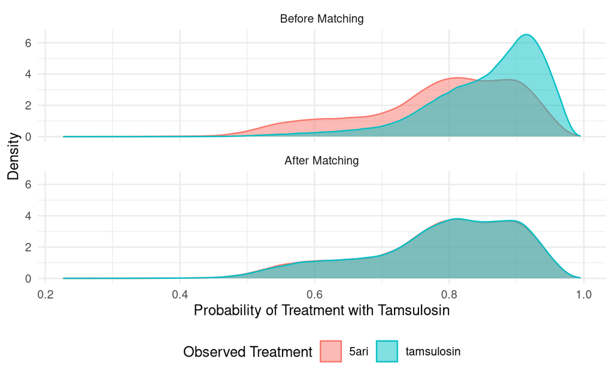

```r
ps <- read_rds(glue::glue("{root_dir}/matching_candidates/tam_5ari.rds"))
bind_rows(
  model_data %>%
    inner_join(ps, by = "enrolid") %>%
    mutate(type = "Before Matching"),
  matched_model_data %>%
    inner_join(ps, by = "enrolid") %>%
    mutate(type = "After Matching")
  ) %>%
  mutate(type = forcats::fct_rev(type)) %>%
  ggplot(aes(x = ptx, fill = drug, color = drug)) +
  geom_density(alpha = 0.5) +
  labs(x = "Probability of Treatment with Tamsulosin",
       y = "Density",
       color = "Observed Treatment",
       fill = "Observed Treatment") +
  theme_minimal() +
  theme(legend.position = "bottom") +
  facet_wrap(~ type, nrow = 2)
```

## Survival Analysis

### Before Matching

Prior to matching, we observe a large survival difference with greater incidence among men taking tamsulosin then 5ARI.

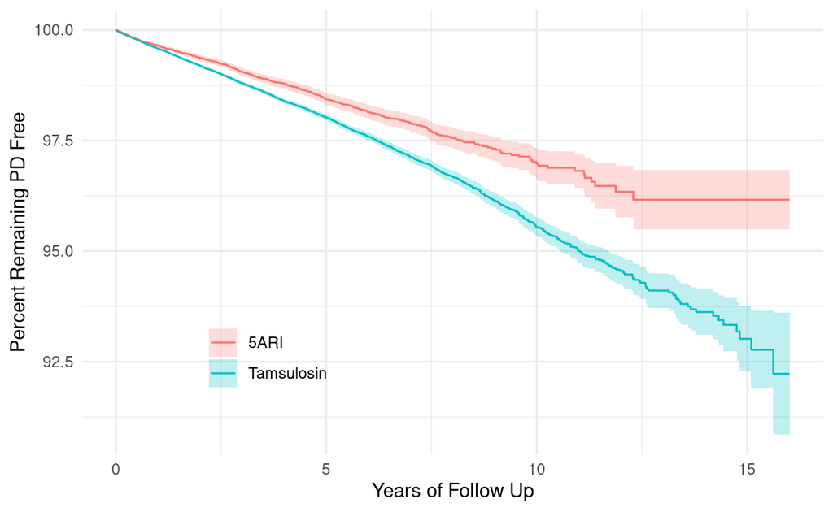

```r
survfit(Surv(survival_time, develops_pd) ~ treatment,
        data = model_data) %>%
  broom::tidy() %>%
  mutate(treatment = ifelse(strata == "treatment=TRUE",
    "Tamsulosin", "5ARI")) %>%
  ggplot(
    aes(
      x = time / 365,
      y = 100 * estimate,
      ymin = 100 * conf.low,
      ymax = 100 * conf.high
    )
  ) +
  geom_step(aes(color = treatment)) +
  geom_ribbon(aes(fill = treatment), alpha = 0.25) +
  theme_minimal() +
  labs(x = "Years of Follow Up", y = "Percent Remaining PD Free",
       color = "", fill = "") +
  theme(legend.position = c(0.25, 0.25))
```

A finding that is statistically significant using the log rank test:

```r
survdiff(Surv(survival_time, develops_pd) ~ treatment,
         data = model_data)
```

```
Call:
survdiff(formula = Surv(survival_time, develops_pd) ~ treatment,
    data = model_data)

                     N Observed Expected (O-E)^2/E (O-E)^2/V
treatment=FALSE  79133      765      973     44.57        54
treatment=TRUE  429741     4867     4659      9.31        54

 Chisq= 54  on 1 degrees of freedom, p= 2e-13
```

```r
raw_cox <- coxph(Surv(survival_time, develops_pd) ~ as.numeric(treatment),
                 data = model_data,
                 robust = TRUE)
tbl_regression(raw_cox, exponentiate = TRUE)
```

| **Characteristic** | **HR**<sup>1</sup> | **95% CI**<sup>1</sup> | **p-value** |
| --- | --- | --- | --- |
| as.numeric(treatment) | 1.33 | 1.23, 1.44 | <0.001 |

<sup>*1*</sup> HR = Hazard Ratio, CI = Confidence Interval

However, this estimate is not trustworthy as we know the groups could be better balanced.

### With Propensity Score Matching

We observe the following overall incidence:

```r
matched_model_data %>%
  group_by(drug) %>%
  summarize(
    cases = sum(develops_pd),
    time = sum(survival_time / 365),
    incidence = cases / time * 10000
  ) %>%
  knitr::kable()
```

| drug | cases | time | incidence |
| --- | --- | --- | --- |
| 5ari | 757 | 241922.9 | 31.29096 |
| tamsulosin | 846 | 241542.2 | 35.02494 |

With a Kaplan Meier curve:

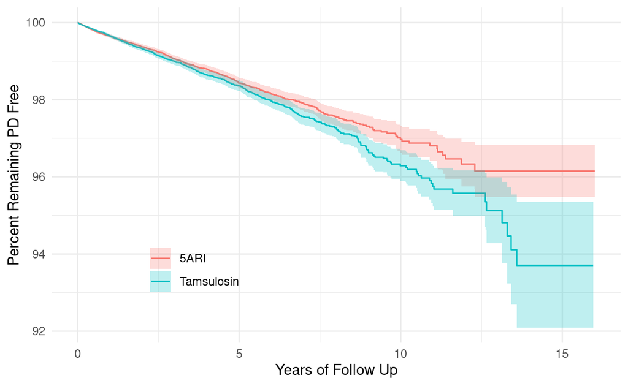

```r
survfit(Surv(survival_time, develops_pd) ~ drug,
        data = matched_model_data) %>%
  broom::tidy() %>%
  mutate(treatment = ifelse(strata == "drug=tamsulosin",
    "Tamsulosin", "5ARI")) %>%
  ggplot(
    aes(
      x = time / 365,
      y = 100 * estimate,
      ymin = 100 * conf.low,
      ymax = 100 * conf.high
    )
  ) +
  geom_step(aes(color = treatment)) +
  geom_ribbon(aes(fill = treatment), alpha = 0.25) +
  theme_minimal() +
  labs(x = "Years of Follow Up", y = "Percent Remaining PD Free",
       color = "", fill = "") +
  theme(legend.position = c(0.25, 0.25))
```

The population size at risk by year is given in the table below:

```r
survfit(Surv(survival_time, develops_pd) ~ drug,
        data = matched_model_data) %>%
  broom::tidy() %>%
  select(strata, time,, n.risk) %>%
  complete(strata, time = 0:(16*365)) %>%
  fill(n.risk, .direction = "down") %>%
  mutate(drug = ifelse(strata == "drug=5ari", "5ARI", "Tamsulosin")) %>%
  select(time, drug, n.risk) %>%
  filter(time %in% c(1:16 * 365)) %>%
  mutate(year = round(time / 365)) %>%
  spread(drug, n.risk) %>%
  knitr::kable()
```

| time | year | 5ARI | Tamsulosin |
| --- | --- | --- | --- |
| 365 | 1 | 58387 | 58426 |
| 730 | 2 | 41709 | 41987 |
| 1095 | 3 | 30354 | 30486 |
| 1460 | 4 | 22122 | 22078 |
| 1825 | 5 | 16032 | 16102 |
| 2190 | 6 | 11475 | 11533 |
| 2555 | 7 | 8076 | 8111 |
| 2920 | 8 | 5471 | 5463 |
| 3285 | 9 | 3584 | 3542 |
| 3650 | 10 | 2238 | 2204 |
| 4015 | 11 | 1316 | 1301 |
| 4380 | 12 | 643 | 658 |
| 4745 | 13 | 328 | 327 |
| 5110 | 14 | 163 | 161 |
| 5475 | 15 | 43 | 48 |
| 5840 | 16 | 2 | 1 |

```r
survdiff(Surv(survival_time, develops_pd) ~ treatment,
         data = matched_model_data)
```

```
Call:
survdiff(formula = Surv(survival_time, develops_pd) ~ treatment,
    data = matched_model_data)

                N Observed Expected (O-E)^2/E (O-E)^2/V
treatment=0 78747      757      802      2.55       5.1
treatment=1 78747      846      801      2.55       5.1

 Chisq= 5.1  on 1 degrees of freedom, p= 0.02
```

Survival times

```r
tbl_survfit(
  survfit(
    Surv(survival_time, develops_pd) ~ drug, data = matched_model_data
  ),
  probs = seq(0.5, 2, by = 0.5) / 100
)
```

| **Characteristic** | **0.5% Percentile** | **1.0% Percentile** | **1.5% Percentile** | **2.0% Percentile** |
| --- | --- | --- | --- | --- |
| drug |  |  |  |  |
| 5ari | 557 (497, 649) | 1,175 (1,067, 1,279) | 1,778 (1,666, 1,943) | 2,385 (2,183, 2,694) |
| tamsulosin | 530 (472, 581) | 1,089 (980, 1,203) | 1,665 (1,519, 1,822) | 2,160 (1,995, 2,365) |

We fit a Cox regression model to estimate the differences in hazard:

```r
full_cox <- coxph(Surv(survival_time, develops_pd) ~ as.numeric(treatment),
                       data = matched_model_data,
                       robust = TRUE)
tbl_regression(full_cox, exponentiate = TRUE)
```

| **Characteristic** | **HR**<sup>1</sup> | **95% CI**<sup>1</sup> | **p-value** |
| --- | --- | --- | --- |
| as.numeric(treatment) | 1.12 | 1.01, 1.23 | 0.024 |

<sup>*1*</sup> HR = Hazard Ratio, CI = Confidence Interval

## Fit Summaries

```r
tbl_merge(
  tbls = list(
    tbl_regression(raw_cox, exponentiate = TRUE),
    tbl_regression(full_cox, exponentiate = TRUE)
  ),
  tab_spanner = c("Unadjusted", "Propensity Score Matched")
) %>%
  as_flex_table()
```

| Characteristic | Unadjusted HR1 | Unadjusted 95% CI1 | Unadjusted p-value | Propensity Score Matched HR1 | Propensity Score Matched 95% CI1 | Propensity Score Matched p-value |
| --- | --- | --- | --- | --- | --- | --- |
| as.numeric(treatment) | 1.33 | 1.23, 1.44 | <0.001 | 1.12 | 1.01, 1.23 | 0.024 |

1HR = Hazard Ratio, CI = Confidence Interval

## Diagnostics

```r
scf_residuals <- cox.zph(full_cox)
scf_residuals
```

```
                      chisq df     p
as.numeric(treatment)  4.94  1 0.026
GLOBAL                 4.94  1 0.026
```

```r
with(scf_residuals, cor.test(x, y))
```

```
    Pearson's product-moment correlation

data:  x and y
t = 2.2253, df = 1601, p-value = 0.0262
alternative hypothesis: true correlation is not equal to 0
95 percent confidence interval:
 0.006587255 0.104205887
sample estimates:
       cor
0.05552927
```

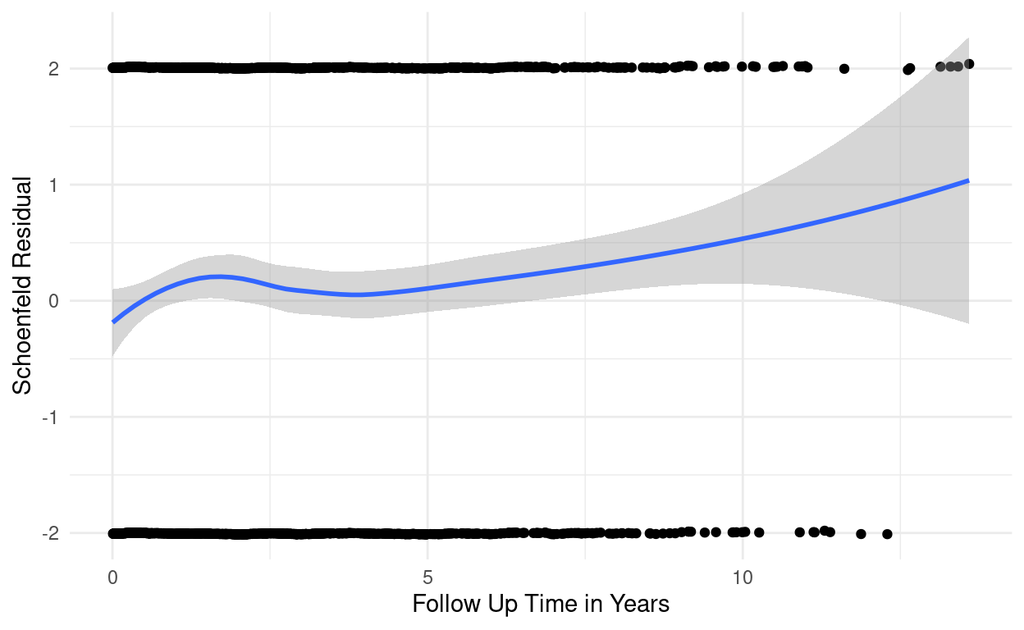

```r
tibble(
  x = scf_residuals$time,
  y = scf_residuals$y
) %>%
  ggplot(aes(x = x / 365, y = y)) +
  geom_point() +
  geom_smooth(method = "loess") +
  labs(x = "Follow Up Time in Years", y = "Schoenfeld Residual") +
  theme_minimal()
```